# Resting Heartrates (flipped assignment 2)

Stephen Ratcliff, Kameron Garza, Forest Kingfisher

2021-09-04

In this analysis, we analyze the resting heart rate data collected on 65 random males and 65 random females. We read the data from a Comma Separated Value (.csv) file posted to the web consisting of three data values per participant:

- `Temp`: body temperature in Fahrenheit degrees),
- `Sex`: biological gender, either male = 1 or female = 2
- `Beats`: heart rate, in beats per minute

```r
#Import normtemp.csv from url
dat <- read.csv("https://raw.githubusercontent.com/tmatis12/datafiles/main/normtemp.csv")
```

### Descriptive Statistics

```r
malebeats = subset(dat,Sex==1)

# Descriptive Statistics
summary(malebeats$Beats)
```

```
##    Min. 1st Qu.  Median    Mean 3rd Qu.    Max.
##   58.00   70.00   73.00   73.37   78.00   86.00
```

```r
# Male Heart Rate Quartiles
quantile(malebeats$Beats)
```

```
##   0%  25%  50%  75% 100%
##   58   70   73   78   86
```

```r
# Sample Standard Deviation
sd(malebeats$Beats)
```

```
## [1] 5.875184
```

### Histograms

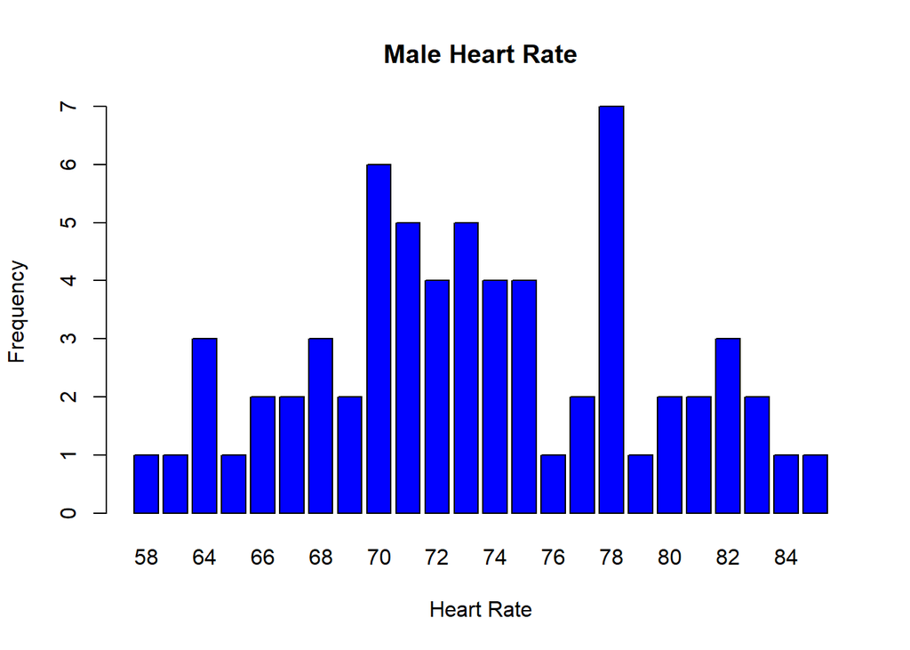

```r
# Male Heart Rate Histogram
barplot(table(malebeats$Beats),xlab = "Heart Rate",ylab = "Frequency",col = "blue",main="Male Heart Rate")
```

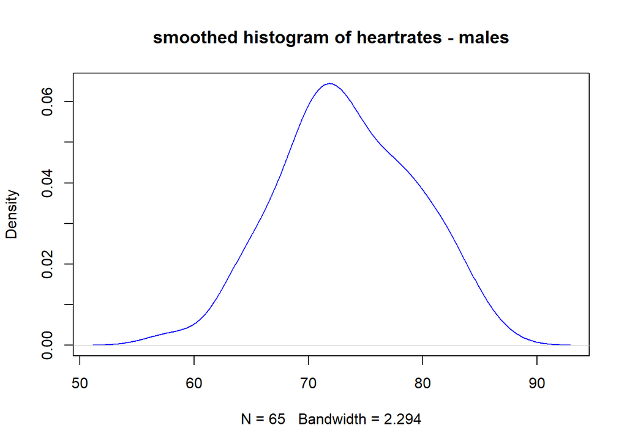

```r
plot(density(malebeats$Beats),col="blue",main="smoothed histogram of heartrates - males")
```

### Normal Probability Plot

Comparing the individual data values for heartrate to a theoretical average line (qqnorm connects central quartiles), the data trends similar to this theoretical linear approximation, apparent even without confidence intervals.

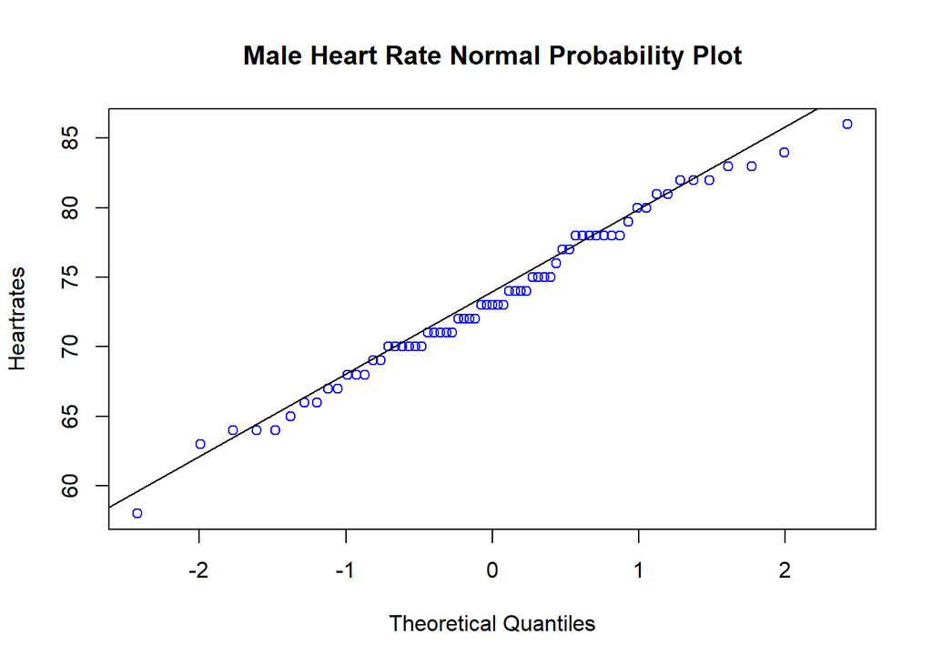

```r
# Male Heart Rate Normal Probability Plot
qqnorm(malebeats$Beats,col = 'blue', main="Male Heart Rate Normal Probability Plot", ylab = "Heartrates")
qqline(malebeats$Beats)
```

# Female Descriptive Statistics

Summary statistics show that the mean and median averages are slightly different, indicating that our distribution is not symetric. However, the first quartile is almost exactly equidistant from the mean as the third, indicating less skew in the overall distribution compared to the asymetry near the mean. This bears more examination in the histograms. The minimum and maximum are within three standard deviations of the mean (between 50 and 98) and median (between 52 and 100), so we have no outliers to investigate.

```r
femalebeats = subset(dat,Sex==2)

# Descriptive Statistics
summary(femalebeats$Beats)
```

```
##    Min. 1st Qu.  Median    Mean 3rd Qu.    Max.
##   57.00   68.00   76.00   74.15   80.00   89.00
```

```r
# Female Heart Rate Quantiles
quantile(femalebeats$Beats)
```

```
##   0%  25%  50%  75% 100%
##   57   68   76   80   89
```

```r
# Sample Standard Deviation
sd(femalebeats$Beats)
```

```
## [1] 8.105227
```

### Histograms

Our histogram shows a flat and wide normal-like distribution with a much more distinct left skew than the male heartrate histogram. Our density histogram confirms that the sample distribution is left-skewed but resembles the distinctive bell-curve shape of a normal distribution.

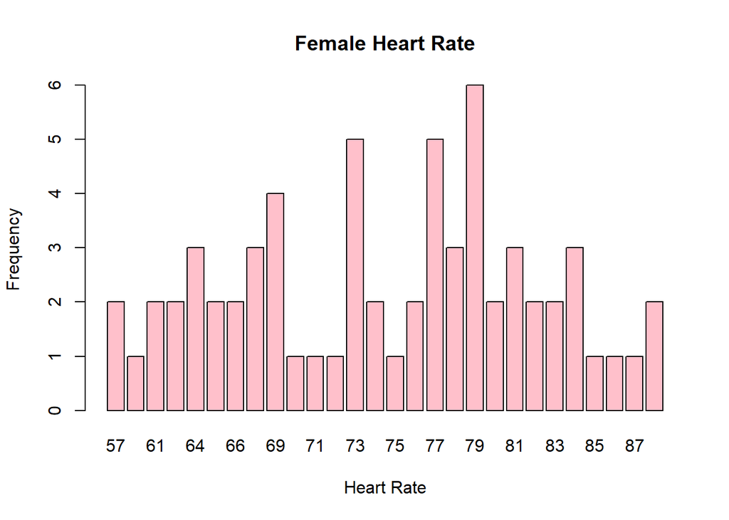

```r
# Female Heart Rate Histogram
barplot(table(femalebeats$Beats),xlab = "Heart Rate",ylab = "Frequency",col = "pink",main="Female Heart Rate")
```

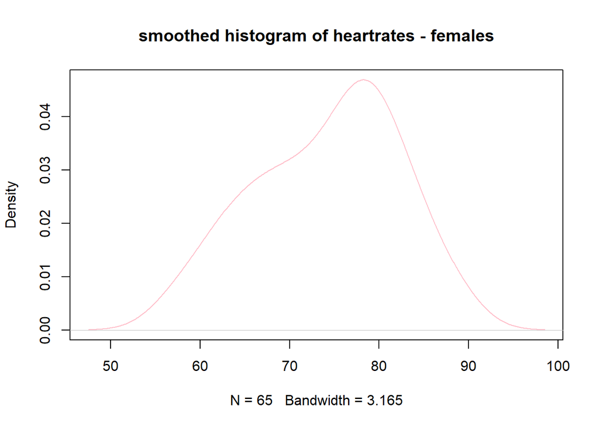

```r
plot(density(femalebeats$Beats),col="pink",main="smoothed histogram of heartrates - females")
```

### Normal Probability Plot

Comparing the individual data values for heartrate to a theoretical average line (qqnorm connects central quartiles), the data trends similar to this theoretical linear approximation, apparent even without confidence intervals.

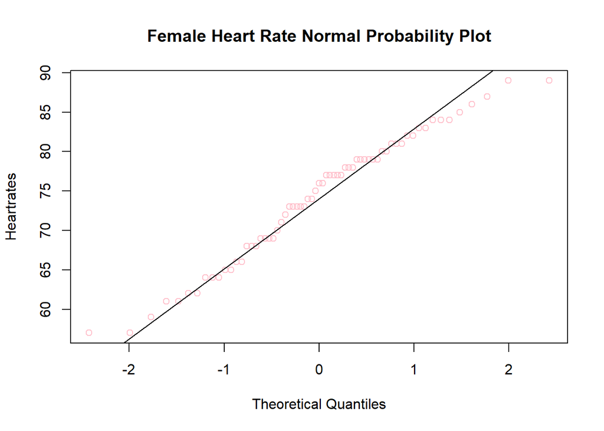

```r
# Female Heart Rate Normal Probability Plot
qqnorm(femalebeats$Beats,col = 'pink', main="Female Heart Rate Normal Probability Plot", ylab = "Heartrates")
qqline(femalebeats$Beats)
```

# Male vs Female Box Plot Comparison

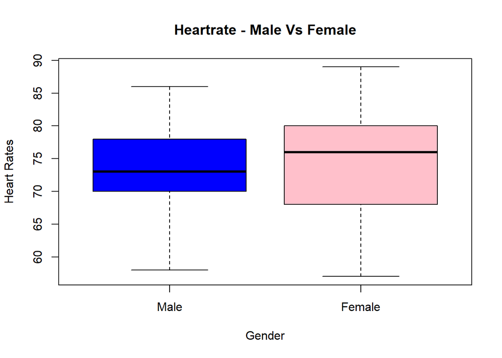

```r
# boxplots comparing males' and females' heartrates
boxplot(Beats~Sex, data = dat, col=c("blue","pink"), names = c("Male", "Female"),xlab = "Gender",ylab = "Heart Rates",main="Heartrate - Male Vs Female")
```

# Complete Code

Here we display the complete R code used in this analysis.

```r
#Import normtemp.csv from url
dat <- read.csv("https://raw.githubusercontent.com/tmatis12/datafiles/main/normtemp.csv")

malebeats = subset(dat,Sex==1)

# Descriptive Statistics
summary(malebeats$Beats)

# Male Heart Rate Quartiles
quantile(malebeats$Beats)

# Sample Standard Deviation
sd(malebeats$Beats)

# Male Heart Rate Histogram
barplot(table(malebeats$Beats),xlab = "Heart Rate",ylab = "Frequency",col = "blue",main="Male Heart Rate")
plot(density(malebeats$Beats),col="blue",main="smoothed histogram of heartrates - males")

# Male Heart Rate Normal Probability Plot
qqnorm(malebeats$Beats,col = 'blue', main="Male Heart Rate Normal Probability Plot", ylab = "Heartrates")
qqline(malebeats$Beats)

femalebeats = subset(dat,Sex==2)

# Descriptive Statistics
summary(femalebeats$Beats)

# Female Heart Rate Quantiles
quantile(femalebeats$Beats)

# Sample Standard Deviation
sd(femalebeats$Beats)

# Female Heart Rate Histogram
barplot(table(femalebeats$Beats),xlab = "Heart Rate",ylab = "Frequency",col = "pink",main="Female Heart Rate")
plot(density(femalebeats$Beats),col="pink",main="smoothed histogram of heartrates - females")

# Female Heart Rate Normal Probability Plot
qqnorm(femalebeats$Beats,col = 'pink', main="Female Heart Rate Normal Probability Plot", ylab = "Heartrates")
qqline(femalebeats$Beats)

# boxplots comparing males' and females' heartrates
boxplot(Beats~Sex, data = dat, col=c("blue","pink"), names = c("Male", "Female"),xlab = "Gender",ylab = "Heart Rates",main="Heartrate - Male Vs Female")
```